# Stat_VR

# 11 Выделение тренда с помощью метода LOESS (local regression)

LOESS - сглаживание с помощью построения локальных линейных регрессий.
LONESS (local weighted regression)- сглаживание с помощью построения локальных взвешенных линейных регрессий.
Другими словами глобальный метод локализуем к кусочкам ряда. Данное сглаживание не обязательно только для ВР, просто для них многие вещи упрощаются.
Например мы можем задать процент ближайших точек к заданной точке x. Для ВР этот процент равностоящих точек и их не надо высчитывать.
Мы можем задать для каждой точке $h$ - половину окна и построить по полученным точка линейную регрессию.Степень гладкости построенных точек зависит от h.
$d$ - порядок полинома. Стандартно d=1 - локальная линейная (биномиальная) регрессия. d=0 - среднее значение (const).
Обе функции используют веса трикубические: (Но в lowess можно еще делать внешние циклы по устранению выбросов с помощью уменьшения их весов. Рассмотрим взвешенную линейную регрессию с трикубическими весами:)
$$w(y)=(1-|\frac{d}{n}|^3)^3, \text{ где } d = dist(y,x).$$

Регрессия Лесса может быть применена с loess()использованием числового вектора, чтобы сгладить его и предсказать Y локально (т. Е. В пределах обученных значений X s ). Размер окрестности можно контролировать с помощью spanаргумента, который находится в диапазоне от 0 до 1. Он контролирует степень сглаживания. Таким образом, чем больше значение span, тем более плавной является подгоночная кривая.  
Переменной предиктора могут быть просто индексы от 1 до количества наблюдений при отсутствии поясняющих переменных. (Ширина окна сглаживания span = 0.2, степень полинома degree = 2)

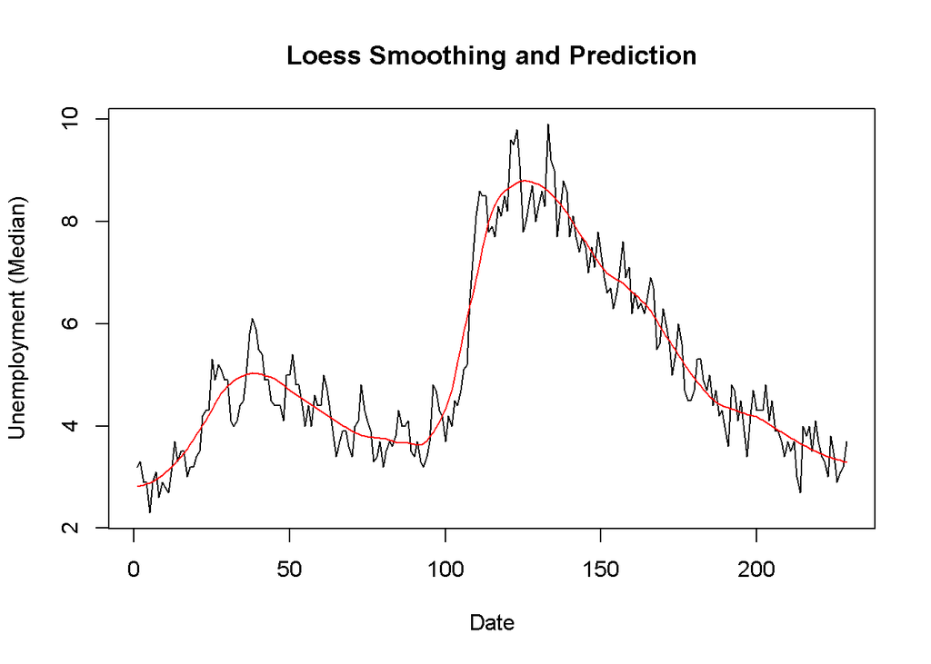

```r
mod_loess <- loess(series$level~ series$DATE, data = series,span = 0.2,degree = 2)
trend.loess <- predict(mod_loess)

plot(series$level, type="l", main="Loess Smoothing and Prediction", xlab="Date", ylab="Unemployment (Median)")
lines(trend.loess, col="red")
```

# 12 Hodrick-Prescott filter

$$h_i=argmin_{s_i} \sum_{i=1}^{N}(x_i - s_i)^2 +\lambda \sum_{i=1}^{N-1} [(s_{i+1}-s_i)-(s_i-s_{i-1})]$$
Вторым слагаемым ищем где вторая производная небольшая.
Также замечаем, чем меньше $\lambda$, тем кривее тренд. Чем больше $\lambda$, тем более гладкий тренд.

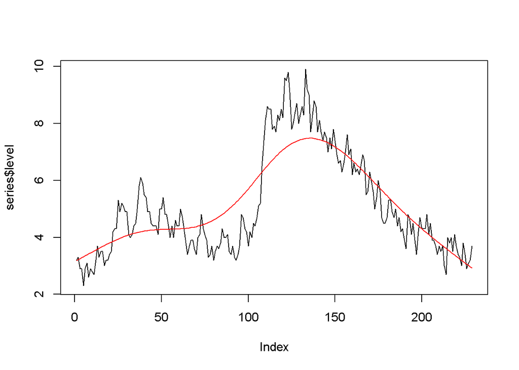

```r
library(mFilter)


mod_hp <- hpfilter(series$level,freq=129600,type="lambda")
plot(series$level,type="l")
lines(mod_hp$trend,col="red")
```

Видим, что тренд более гладкий, давайте возьмем другое значение $\lambda$.

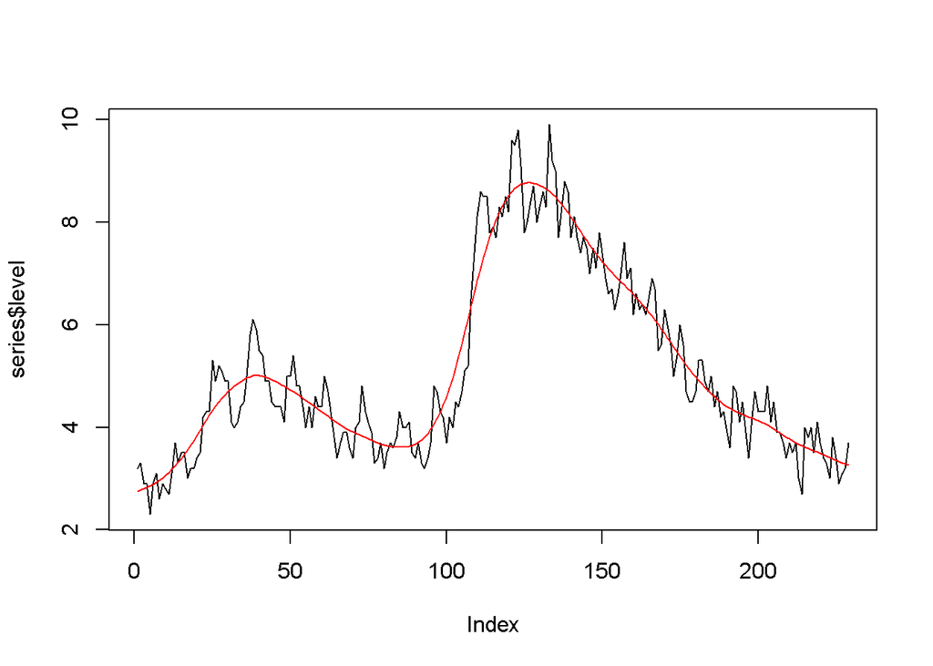

```r
mod_hp <- hpfilter(series$level,freq=1200,type="lambda")
plot(series$level,type="l")
lines(mod_hp$trend,col="red")
```